# Project - Bank Churn Prediction

## **Background and Context:**

Businesses like banks that provide service have to worry about the problem of 'Churn' i.e. customers leaving and joining another service provider. It is important to understand which aspects of the service influence a customer's decision in this regard. Management can concentrate efforts on the improvement of service, keeping in mind these priorities.

## **Objective:**

- Given a Bank customer, build a neural network-based classifier that can determine whether they will leave or not in the next 6 months.

## **Data Description:**

- The case study is from an open-source dataset from Kaggle. The dataset contains 10,000 sample points with 14 distinct features such as CustomerId, CreditScore, Geography, Gender, Age, Tenure, Balance, etc.

## **Data Dictionary:**

```
RowNumber: Row number
CustomerId: Unique identification key for different customers
Surname: Surname of the customer
Credit Score: A credit score is a measure of an individual's ability to pay back the borrowed amount. It is the numerical representation of their creditworthiness. A credit score is a 3-digit number that falls in the range of 300-900, 900 being the highest
Geography: The country to which the customer belongs
Gender: The gender of the customer
Age: Age of the customer
Tenure: The period of time a customer has been associated with the bank
Balance: The account balance (the amount of money deposited in the bank account) of the customer
NumOfProducts: How many accounts, bank account affiliated products the person has
HasCrCard: Does the customer have a credit card through the bank?
IsActiveMember: Subjective, but for the concept
EstimatedSalary: Estimated salary of the customer
Exited: Did they leave the bank after all?
```

## Index

- Overview of the dataset
- EDA
- Data Pre-processing
- Model Building
- Model Performance Evaluation
- Conclusion and Key Takeaways

## Overview of the dataset

### Reading Dataset and Feature Elimination (5 points)

- Read the dataset properly - Print the overview of the data (statistical summary, shape, info, etc) - Eliminate the unique features from the dataset with proper reasoning

**Let's start by importing libraries we need.**

```python
#importing tensorflow
import tensorflow as tf
print(tf.__version__)
```

```
2.5.0
```

```python
import pandas as pd
import numpy as np
import matplotlib.pyplot as plt
%matplotlib inline
import seaborn as sns
sns.set_theme()

from sklearn import preprocessing
from sklearn.model_selection import train_test_split
from sklearn.decomposition import PCA
from sklearn.metrics import accuracy_score, confusion_matrix, precision_score
from sklearn.metrics import recall_score, f1_score, precision_recall_curve, auc

import tensorflow as tf
from tensorflow import keras
from tensorflow.keras import layers
from tensorflow.keras import models
from tensorflow.keras import optimizers
```

```python
#Loading dataset
data=pd.read_csv("bank.csv")
```

**View the first rows of the dataset.**

```python
data.head()
```

|  | RowNumber | CustomerId | Surname | CreditScore | Geography | Gender | Age | Tenure | Balance | NumOfProducts | HasCrCard | IsActiveMember | EstimatedSalary | Exited |
| --- | --- | --- | --- | --- | --- | --- | --- | --- | --- | --- | --- | --- | --- | --- |
| 0 | 1 | 15634602 | Hargrave | 619 | France | Female | 42 | 2 | 0.00 | 1 | 1 | 1 | 101348.88 | 1 |
| 1 | 2 | 15647311 | Hill | 608 | Spain | Female | 41 | 1 | 83807.86 | 1 | 0 | 1 | 112542.58 | 0 |
| 2 | 3 | 15619304 | Onio | 502 | France | Female | 42 | 8 | 159660.80 | 3 | 1 | 0 | 113931.57 | 1 |
| 3 | 4 | 15701354 | Boni | 699 | France | Female | 39 | 1 | 0.00 | 2 | 0 | 0 | 93826.63 | 0 |
| 4 | 5 | 15737888 | Mitchell | 850 | Spain | Female | 43 | 2 | 125510.82 | 1 | 1 | 1 | 79084.10 | 0 |

**Check data types and number of non-null values for each column.**

```python
print(data.shape)
data.info()
```

```
(10000, 14)
<class 'pandas.core.frame.DataFrame'>
RangeIndex: 10000 entries, 0 to 9999
Data columns (total 14 columns):
 #   Column           Non-Null Count  Dtype
---  ------           --------------  -----
 0   RowNumber        10000 non-null  int64
 1   CustomerId       10000 non-null  int64
 2   Surname          10000 non-null  object
 3   CreditScore      10000 non-null  int64
 4   Geography        10000 non-null  object
 5   Gender           10000 non-null  object
 6   Age              10000 non-null  int64
 7   Tenure           10000 non-null  int64
 8   Balance          10000 non-null  float64
 9   NumOfProducts    10000 non-null  int64
 10  HasCrCard        10000 non-null  int64
 11  IsActiveMember   10000 non-null  int64
 12  EstimatedSalary  10000 non-null  float64
 13  Exited           10000 non-null  int64
dtypes: float64(2), int64(9), object(3)
memory usage: 1.1+ MB
```

- We can see that there are total 14 columns and 10000 rows in the dataset.
- There are several columns' data type: integer, float and object.
- The non-null values of each column is equal to the number of total rows in the dataset i.e. there are not null values.
- There are columns that clearly they dont bring information on the problem of question: RowNumber, CustomerId, Surname.
- The columns Balance and EstimatedSalary can be rounded to integer values.

```python
#The RowNumber, CustomerId, Surname columns can be dropped because they dont bring any relevant information
data1 = data.drop(columns=['RowNumber', 'CustomerId', 'Surname']).copy()
#The columns Balance and EstimatedSalary are cast to integer values
data1[['Balance', 'EstimatedSalary']] = data1[['Balance', 'EstimatedSalary']].astype('int64')
print(data1.info())
data1.head()
```

```
<class 'pandas.core.frame.DataFrame'>
RangeIndex: 10000 entries, 0 to 9999
Data columns (total 11 columns):
 #   Column           Non-Null Count  Dtype
---  ------           --------------  -----
 0   CreditScore      10000 non-null  int64
 1   Geography        10000 non-null  object
 2   Gender           10000 non-null  object
 3   Age              10000 non-null  int64
 4   Tenure           10000 non-null  int64
 5   Balance          10000 non-null  int64
 6   NumOfProducts    10000 non-null  int64
 7   HasCrCard        10000 non-null  int64
 8   IsActiveMember   10000 non-null  int64
 9   EstimatedSalary  10000 non-null  int64
 10  Exited           10000 non-null  int64
dtypes: int64(9), object(2)
memory usage: 859.5+ KB
None
```

|  | CreditScore | Geography | Gender | Age | Tenure | Balance | NumOfProducts | HasCrCard | IsActiveMember | EstimatedSalary | Exited |
| --- | --- | --- | --- | --- | --- | --- | --- | --- | --- | --- | --- |
| 0 | 619 | France | Female | 42 | 2 | 0 | 1 | 1 | 1 | 101348 | 1 |
| 1 | 608 | Spain | Female | 41 | 1 | 83807 | 1 | 0 | 1 | 112542 | 0 |
| 2 | 502 | France | Female | 42 | 8 | 159660 | 3 | 1 | 0 | 113931 | 1 |
| 3 | 699 | France | Female | 39 | 1 | 0 | 2 | 0 | 0 | 93826 | 0 |
| 4 | 850 | Spain | Female | 43 | 2 | 125510 | 1 | 1 | 1 | 79084 | 0 |

```python
#Number of distinct categories in Exited column
data1['Exited'].nunique()
```

```
2
```

- As expected, there are only 2 classes: 0 (non exited) and 1 (exited)

```python
#Checking the percentage of each class in the Exited column
(data1.Exited.value_counts())/(data1.Exited.count())
```

```
0    0.7963
1    0.2037
Name: Exited, dtype: float64
```

- There are 79.63% 'Non Exited' (0) instances and 20.37% 'Exited' (1) instances. This means that there is a high percentage of customers leaving the services of the bank.

```python
#Total of null data by rows
data1.isna().sum()
```

```
CreditScore        0
Geography          0
Gender             0
Age                0
Tenure             0
Balance            0
NumOfProducts      0
HasCrCard          0
IsActiveMember     0
EstimatedSalary    0
Exited             0
dtype: int64
```

```python
#Total of number of rows with some null data
data1.isnull().any(axis=1).sum()
```

```
0
```

```python
#Lets check duplicate observations
data1.duplicated().sum()
```

```
0
```

- There are no null data neither duplicated rows.
- We can see in this final set there are 10000 rows with 9 columns of integer data and 2 columns of categorical variables in the dataset.

## EDA

### Perform and Exploratory Data Analysis on the data (10 points)

- Bivariate analysis - Use appropriate visualizations to identify the patterns and insights - Any other exploratory deep dive

**Summary of the dataset**

```python
#Summary of columns
data1.describe().T
```

|  | count | mean | std | min | 25% | 50% | 75% | max |
| --- | --- | --- | --- | --- | --- | --- | --- | --- |
| CreditScore | 10000.0 | 650.5288 | 96.653299 | 350.0 | 584.00 | 652.0 | 718.00 | 850.0 |
| Age | 10000.0 | 38.9218 | 10.487806 | 18.0 | 32.00 | 37.0 | 44.00 | 92.0 |
| Tenure | 10000.0 | 5.0128 | 2.892174 | 0.0 | 3.00 | 5.0 | 7.00 | 10.0 |
| Balance | 10000.0 | 76485.5715 | 62397.185107 | 0.0 | 0.00 | 97198.0 | 127643.75 | 250898.0 |
| NumOfProducts | 10000.0 | 1.5302 | 0.581654 | 1.0 | 1.00 | 1.0 | 2.00 | 4.0 |
| HasCrCard | 10000.0 | 0.7055 | 0.455840 | 0.0 | 0.00 | 1.0 | 1.00 | 1.0 |
| IsActiveMember | 10000.0 | 0.5151 | 0.499797 | 0.0 | 0.00 | 1.0 | 1.00 | 1.0 |
| EstimatedSalary | 10000.0 | 100089.7484 | 57510.491042 | 11.0 | 51001.75 | 100193.5 | 149387.75 | 199992.0 |
| Exited | 10000.0 | 0.2037 | 0.402769 | 0.0 | 0.00 | 0.0 | 0.00 | 1.0 |

- Mean and median value of 'CreditScore' is approx 650.
- Mean and median value for 'Age' are approx 39 and 37, respectively.
- Mean and median value for 'Tenure' is approx 5.
- Mean and median value for 'Balance' are approx 76500 and 97200, respectively.
- Mean and median value for 'NumOfProducts' are approx 1.5 and 1, respectively.
- Mean and median value for 'HasCrCard' are approx 0.7 and 1, respectively.
- Mean and median value for 'IsActiveMember' are approx 0.5 and 1, respectively.
- Mean and median value for 'EstimatedSalary' is approx 100100.

**Number of unique values in each column**

```python
data1.nunique()
```

```
CreditScore         460
Geography             3
Gender                2
Age                  70
Tenure               11
Balance            6205
NumOfProducts         4
HasCrCard             2
IsActiveMember        2
EstimatedSalary    9770
Exited                2
dtype: int64
```

- 'HasCrCard' and 'IsActiveMember' are also binary variables that can be converted in dummies variables, such as we will convert the categorical variables 'Geography' and 'Gender'.

**Grouping of data values**

```python
#we check number of grades in the different columns presenting with a few values
print(data1['Geography'].value_counts())
print(data1['Gender'].value_counts())
print(data1['NumOfProducts'].value_counts())
print(data1['HasCrCard'].value_counts())
print(data1['IsActiveMember'].value_counts())
```

```
France     5014
Germany    2509
Spain      2477
Name: Geography, dtype: int64
Male      5457
Female    4543
Name: Gender, dtype: int64
1    5084
2    4590
3     266
4      60
Name: NumOfProducts, dtype: int64
1    7055
0    2945
Name: HasCrCard, dtype: int64
1    5151
0    4849
Name: IsActiveMember, dtype: int64
```

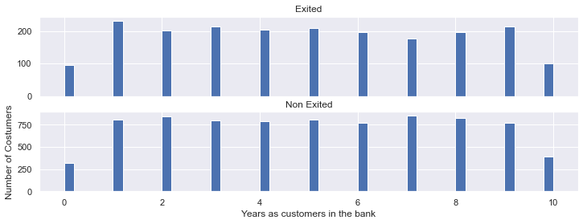

```python
#Histogram for feature Tenure
f, (ax1, ax2) = plt.subplots(2, 1, sharex=True, figsize=(12,4))

ax1.hist(data["Tenure"][data["Exited"] == 1], bins = 50)
ax1.set_title('Exited')

ax2.hist(data["Tenure"][data["Exited"] == 0], bins = 50)
ax2.set_title('Non Exited')

plt.xlabel('Years as customers in the bank')
plt.ylabel('Number of Costumers')
plt.show()
```

- It seems there is no correlation between the Tenure of the costumer and the possibility to leave the bank.

```
Index(['CreditScore'], dtype='object')
```

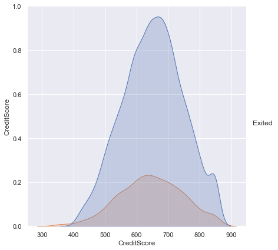

```
Index(['Age', 'Tenure', 'Balance', 'NumOfProducts', 'HasCrCard',
       'IsActiveMember', 'EstimatedSalary'],
      dtype='object')
```

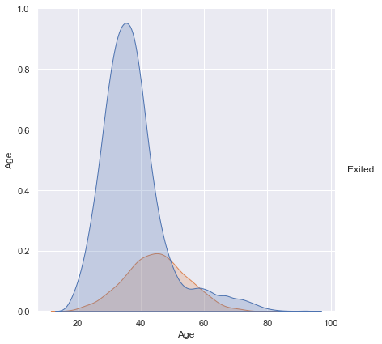

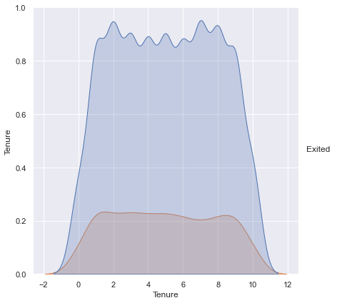

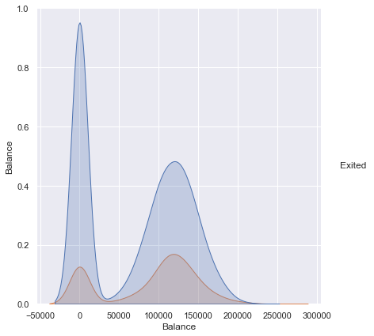

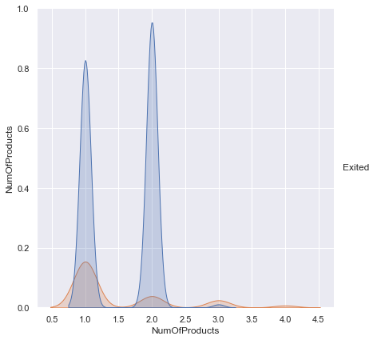

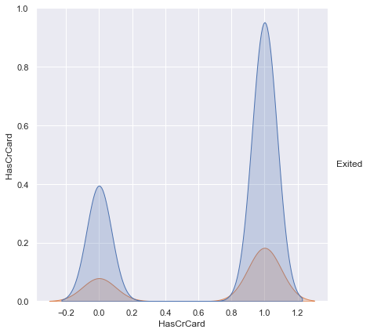

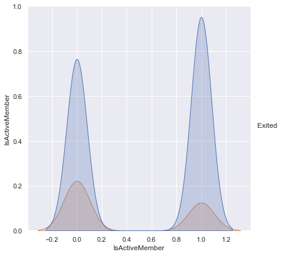

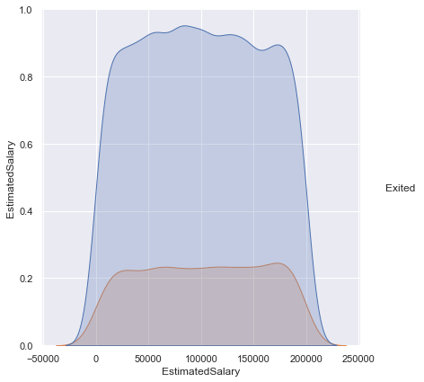

```python
#We plot the distribution of each variable grouping by the Exited
#Here the column 1 = CreditScore
columnas = data1.columns[0:1]
print(columnas)
for i in columnas:
    plt.figure(figsize=(30,30))
    sns.pairplot(data1, x_vars=[i],y_vars=[i], hue = 'Exited', height=6)
    plt.show()

#Columns 2 and 3 are categorical then we jump them and plot the rest of columns
columnas = data1.columns[3:10]
print(columnas)
for i in columnas:
    plt.figure(figsize=(30,30))
    sns.pairplot(data1, x_vars=[i],y_vars=[i], hue = 'Exited', height=6)
    plt.show()
```

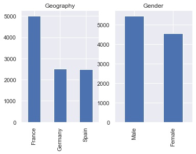

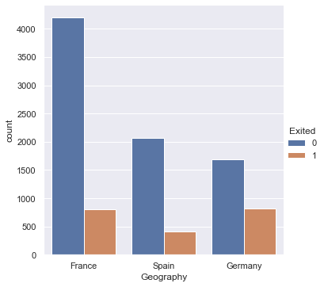

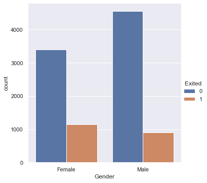

```python
#Plot of the categorical variables
categorical_features = ["Geography", "Gender"]
fig, ax = plt.subplots(1, len(categorical_features))
for i, categorical_feature in enumerate(data1[categorical_features]):
    data1[categorical_feature].value_counts().plot(kind="bar", ax=ax[i]).set_title(categorical_feature)
    sns.catplot(x=categorical_feature, hue="Exited", kind="count", data=data1)
fig.show()
```

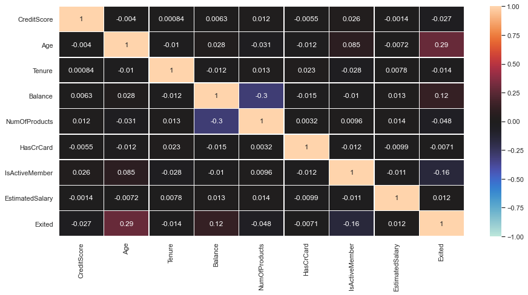

```python
# selecting numerical columns, in this case all the 5 existing columns
all_col = data1.select_dtypes(include=np.number).columns.tolist()
#num_plots = len(all_col)
plt.figure(figsize=(15,7))

sns.heatmap(data1[all_col].corr(),
            annot=True,
            linewidths=0.5,vmin=-1,vmax=1,
            center=0,
            cbar=True,)

plt.show()
```

**Observations**

- At a first sight, looking at the pairplots the majority of the variables seem to have some influence on the Exited column but evidently some of them are relevant and other ones can be discarded.
- We can better highlight these dependencies with the correlation function.
- HasCrCard, EstimatedSalary, Tenure and CreditScore present a very low correlation with the Exited variable and according to visual plots we can discard these columns for the construction of the model.
- NumOfProducts, Balance, IsActiveMember and Age seem to be the variables more influent on the Exited feature.
- Also the Gender and Geography seem to have disparity in order to influence on the Exited column.
- Then, we will maintain these last 6 features in order to construct the model for this problem.